# WILD 591 – Spatial Population Modeling

Lesson 2: Spatial Patterns

Mahdieh Tourani

2026-10-16

# Where we’re going

## Roadmap for today

1. Dependence in data due to space
2. Non-spatial Regression
3. Space-environment relationship

# 1. Spatial structure

## Autocorrelation

> Tobler’s First Law of Geography: “Everything is related to everything else, but near things are more related than distant things”

**Autocorrelation** is the relationship between values of a variable with itself according to distance.

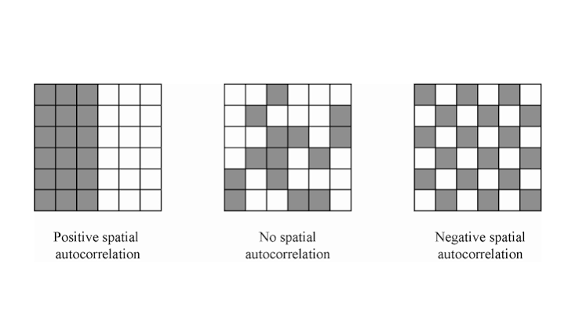

## Processes

**SA-env**: Spatial structure of the environment

**SD**: Spatial dependence of species response to spatially structured environment

**SA-sp**: Spatial autocorrelation of the species

## Spatial structure

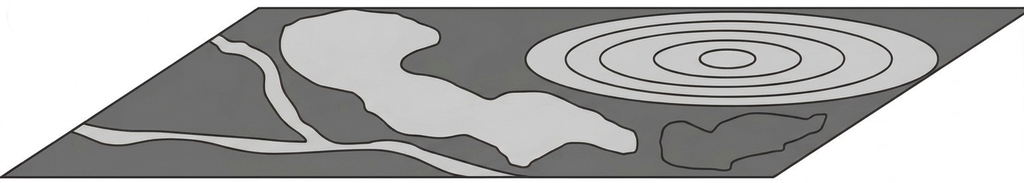

Spatially distributed environmental factors

## Spatial structure due to dependence

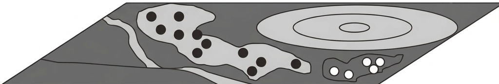

Spatially distributed seeds due to spatially distributed environmental factors

## Spatial structure = Autocorrelation + Dependence

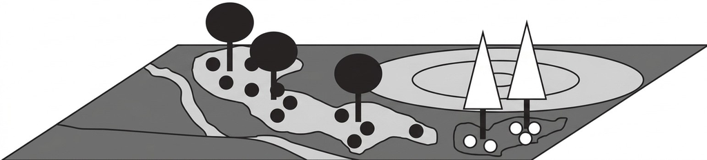

Spatially distributed seeds due to dispersal processes from the trees and the spatially distributed environmental factor

# 1.2 Simulate non/random locations

## Check your environment

Now confirm plotting works:

```r
plot(1:10,
     (1:10) ^ 2,
     pch = 19,
     col = "steelblue",
     xlab = "x",
     ylab = "x squared",
     main = "If you can see this, you're set")
```

## Locations are data too

Same abundance values, two different spatial arrangements:

```r
set.seed(42)
n <- 100
pop <- rpois(n, lambda = 8)

# Arrangement A: locations assigned at random
xa <- runif(n, 0, 10)
ya <- runif(n, 0, 10)

# Arrangement B: high counts placed toward the east
xb <- numeric(n)
xb[order(pop)] <- sort(runif(n, 0, 10))
yb <- runif(n, 0, 10)

par(mfrow = c(1, 2), mar = c(4, 4, 3, 1))
plot(xa,
     ya,
     cex = pop / 4,
     pch = 19,
     col = "grey40",
     main = "A: random arrangement",
     xlab = "Easting",
     ylab = "Northing")
plot(xb,
     yb,
     cex = pop / 4,
     pch = 19,
     col = "firebrick",
     main = "B: structured arrangement",
     xlab = "Easting",
     ylab = "Northing")
```

## Quantifying the difference

For a crude first look, let’s correlate the value with its coordinate:

```r
cor(xa, pop)   # random arrangement
cor(xb, pop)   # structured arrangement
```

Before looking at the second number, guess its sign and rough magnitude from the two maps on the previous slide. Then check yourself.

# 1.3 Simulate species-environment relationship

## Simulate SA-env

The environment is autocorrelated before any organism responds. Here, we build an spatially autocorrelated environment.

```r
set.seed(42)
n <- 40
noise <- matrix(rnorm(n * n), n, n)
smooth_field <- function(m, w) {
  out <- m
  for (i in seq_len(nrow(m))) {
    for (j in seq_len(ncol(m))) {
      ri <- max(1, i - w) : min(nrow(m), i + w)
      rj <- max(1, j - w) : min(ncol(m), j + w)
      out[i, j] <- mean(m[ri, rj])
    } #j
  } #i
  out
  }
```

> What are the outputs of this code chunk?

## Range of autocorrelation

Try with different range of autocorrelation: w = 4 first, and then re-run with w = 1 and w = 10.

```r
## w is the smoothing half-width: the range of autocorrelation.
env <- smooth_field(noise, w = 4)
op <- par(mfrow = c(1, 2), mar = c(1, 1, 3, 1))
image(noise,
      col = hcl.colors(24, "YlGnBu"),
      asp = 1,
      axes = FALSE,
      main = "No autocorrelation",
      col.main = "#70002E")
image(env,
      col = hcl.colors(24, "YlGnBu"),
      asp = 1,
      axes = FALSE,
      main = "SA-env",
      col.main = "#70002E")
par(op)
```

## Autocorrelated environment/species

Environment could be spatially structured (**SA-env**) *and* species clusters for endogenous reasons (**SA-sp**).

```r
set.seed(7)
n <- 40
smooth_field <- function(m, w) {
  out <- m
  for (i in seq_len(nrow(m))) {
    for (j in seq_len(ncol(m))) {
      ri <- max(1, i - w) : min(nrow(m), i + w)
      rj <- max(1, j - w) : min(ncol(m), j + w)
      out[i, j] <- mean(m[ri, rj])
    }
  }
  out
  }
env    <- smooth_field(matrix(rnorm(n * n), n, n), w = 5)
clump  <- smooth_field(matrix(rnorm(n * n), n, n), w = 3)
```

# 2.1 Regression

## Model schematic

When there is no spatial dependence:

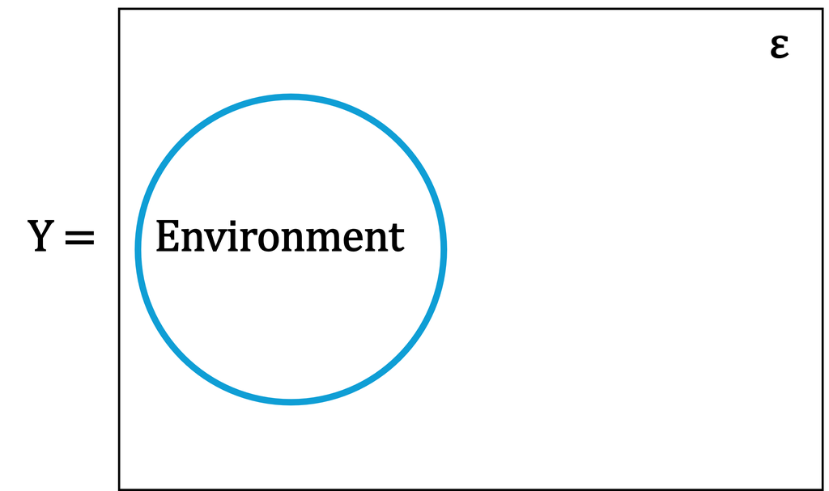

## Model structure

Statistical models describe:

- **Systematic pattern** in a random variable (response), possibly as a function of covariates
- **Random (unexplained) variability** around the mean:

Response = systematic + random

**Note**

other pairs of terms: deterministic + stochastic, or mean + dispersion structure of model

## Key elements of a model

Deterministic process:

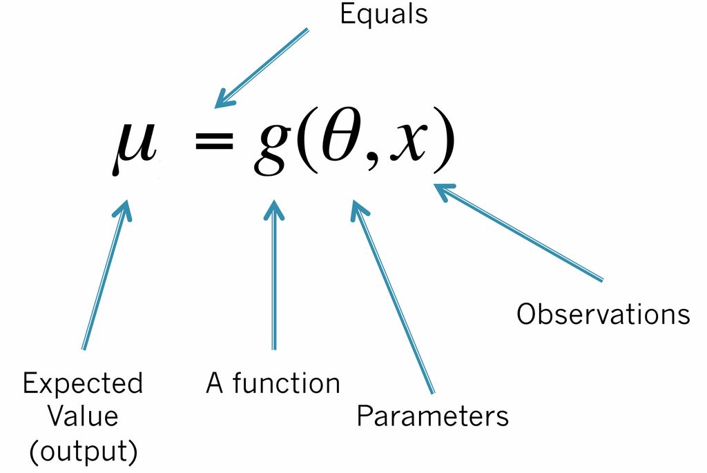

Stochastic process:

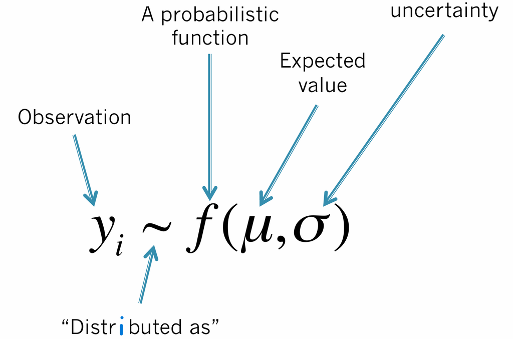

> Why do we need both? Deterministic part is a mathematical model of a process while stochastic part is a statistical model of data that arise from the process.

## Basic regression model

*Deterministic process*: What biological process underlies the pattern in my data?

*Stochastic process*: What probabilistic process produces the values of my data?

$$y_i = \beta_0 + \beta_1 x_i + \epsilon_i, \qquad \epsilon_i \sim {Normal}(0, \sigma^2)$$

is exactly the same as:

$$\mu_i = \beta_0 + \beta_1 x_i, \qquad y_i \sim {Normal}(\mu_i, \sigma^2)$$

> **What if the errors aren’t normal?**

## Model assumptions

Linear regression assumes:

- **Linearity** — the relationship between predictors and response is linear
- **Independence** — errors are independent of each other
- **Homoscedasticity** — constant error variance
- **Normality** — residuals are normally distributed

**Note**

Assumptions are often violated by real data, but we have tools to detect and address them.

> **Which violation is relevant to spatial analysis?**

## Group membership

Sometimes observations within a group share more in common with each other than with observations from other groups, violating the **independence** assumption.

- Group membership can be modeled as a **random effect**

## Spatial group membership

Observations of one individual animal have more in common compared to observations of other individuals. The grouping of observations could also be spatial:

- Camera deployments deployed as clusters within an array
- Plots nested inside stands, transects nested inside watersheds
- Repeat visits to the same site

Cameras a few hundred metres apart sit in the same stand, see the same individuals, and share whatever we failed to measure. **They are not independent samples of the landscape.**

**Important**

Deploying 72 cameras does not buy you 72 independent observations. If they are clustered, the effective sample size is closer to the number of clusters.

# 2.2 Space-environment relationship

## Independent errors

> Spatially independent errors means that there is no spatial autocorrelation neither in the response nor in the environment.

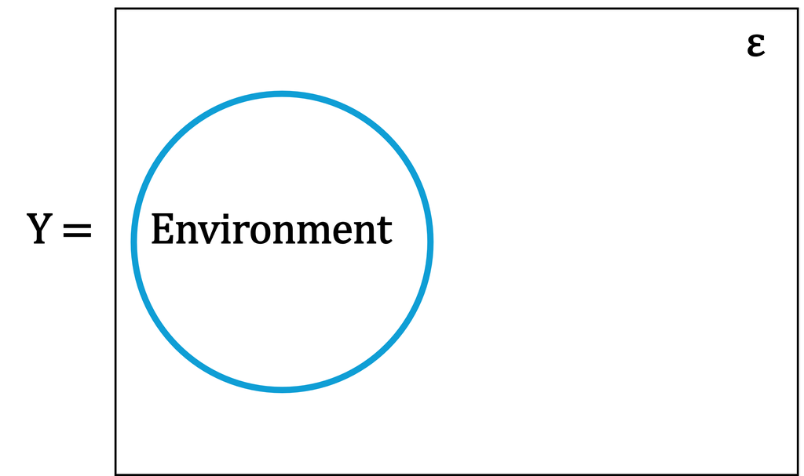

## Friend or foe

When there is spatial dependence, the overlap (covariability) is often a statistical nuisance. But, other times, space might be a parameter in the model.

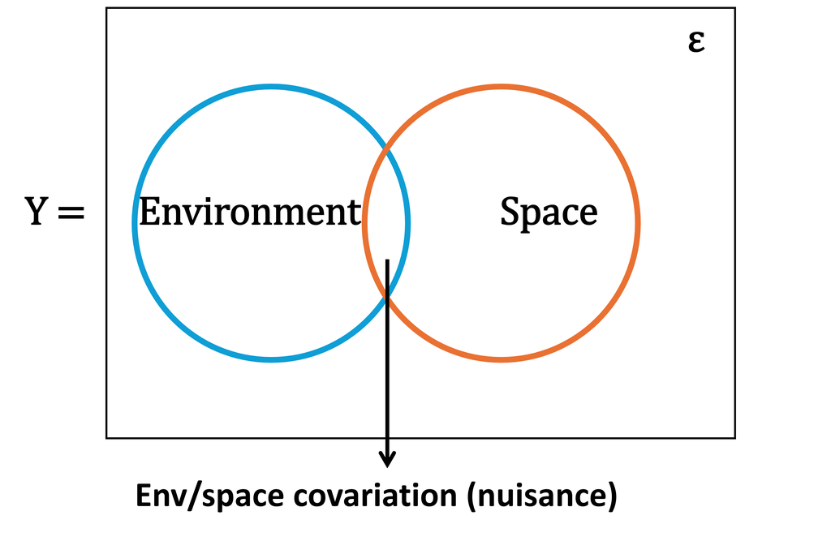

# 3.1 Incorporating space

## Spatial models?

Based on friend or foe, there are two general model types referred to as “spatial regression”.

1. Spatial process creates spatial autocorrelation that has to be accounted for. e.g., GLMM, GAMM, Autoregressive models.
2. Multiple processes play at different spatial scales and we need to partial out spatial variation at all scales.

## Example camera trap data

We **simulate** a camera trap survey so we know the truth and can check what each model recovers:

- **12 camera arrays** scattered across a 20 × 20 km landscape
- **6 deployments per array**, each within a few hundred metres of the array centre
- Response: detection rate (detections per 100 trap-nights)
- Covariate: canopy cover at the deployment
- Grouping: `array_id`

## Simulate the camera array

```r
rm(list = ls())
set.seed(541)

n_array <- 12                       # camera arrays
n_cam   <- 6                        # deployments per array
n       <- n_array * n_cam

# Array centres scattered across a 20 x 20 km landscape
ax <- runif(n_array, 1, 19)
ay <- runif(n_array, 1, 19)

# Deployments sit within ~300 m of their array centre
grp <- rep(seq_len(n_array), each = n_cam)
x   <- ax[grp] + rnorm(n, 0, 0.3)
y   <- ay[grp] + rnorm(n, 0, 0.3)

# Canopy cover varies both among arrays and among deployments within an array
canopy <- rnorm(n_array, 55, 8)[grp] + rnorm(n, 0, 10)
canopy <- pmin(pmax(canopy, 5), 95)

head(data.frame(array = grp,
                x = round(x, 2),
                y = round(y, 2),
                canopy = round(canopy, 1)),
     8)
```

## Simulate the response

```r
# ---- true parameter values ----
b0       <- 8.0     # intercept
b1       <- 2.5     # effect of canopy cover
sd_array <- 2.5     # among-array SD  (the random effect)
sd_resid <- 1.2     # among-deployment SD (residual noise)

z_canopy <- as.numeric(scale(canopy))

a    <- rnorm(n_array, 0, sd_array)              # one draw per array
rate <- b0 + b1 * z_canopy + a[grp] + rnorm(n, 0, sd_resid)

cams <- data.frame( array_id = factor(sprintf("A%02d", grp)),
                    cam.id   = sprintf("A%02d-C%d", grp, rep(1:n_cam, n_array)),
                    x = x,
                    y = y,
                    canopy = canopy,
                    z_canopy = z_canopy,
                    rate = rate)
str(cams)
```

The intraclass correlation we built in is $2.5^2 / (2.5^2 + 1.2^2) \approx 0.81$: most of the variation is **among** arrays, not among deployments within them.

## Where the cameras are

Each colour is one array. The six deployments in a cluster are so close together that at this scale they nearly overlap and that is the whole problem.

```r
array_colors <- hcl.colors(n_array, "Dark 3")
names(array_colors) <- levels(cams$array_id)

plot(y ~ x,
     data = cams,
     col = array_colors[cams$array_id],
     pch = 19,
     cex = 1.3,
     asp = 1,
     xlab = "Easting (km)",
     ylab = "Northing (km)",
     main = "12 arrays, 6 deployments each")
text(ax, ay + 0.9, labels = levels(cams$array_id), cex = 0.7, col = "#333333")
```

## Explore the data

```r
plot(rate ~ z_canopy,
     data = cams,
     col = array_colors[cams$array_id],
     pch = 19,
     cex = 1.3,
     xlab = "Canopy cover (standardised)",
     ylab = "Detections per 100 trap-nights")
legend("topleft",
       bty = "n",
       ncol = 3,
       cex = 0.7,
       legend = levels(cams$array_id),
       pch = 19,
       col = array_colors)
```

There is a clear canopy gradient, but the points also separate into coloured bands.

## How close is too close?

Deployments in the same array are typically under 1 km apart; deployments in different arrays are many kilometres apart. There is no overlap between the two, which is what makes `array_id` a clean grouping variable here.

```r
d    <- as.matrix(dist(cbind(cams$x, cams$y)))
same <- outer(as.character(cams$array_id), as.character(cams$array_id), "==")
ok   <- upper.tri(d)

round(tapply(d[ok], same[ok], summary)$`TRUE`, 2)   # within-array distances
round(tapply(d[ok], same[ok], median), 2)           # median, by group
```

## The dependence, made visible

If residuals were independent, both boxes would include zero. Same-array pairs are strongly positive: when one camera in a cluster is above the line, its neighbours are too.

```r
m_naive <- lm(rate ~ z_canopy, data = cams)   # ignores the grouping entirely
r <- residuals(m_naive)

pr <- outer(r, r)                             # product of residual pairs

boxplot(pr[ok] ~ same[ok],
        names = c("Different array", "Same array"),
        col   = c("#DFD1A7", "#70002E"),
        ylab  = "Product of residual pair", xlab = "")
abline(h = 0, lty = 2, lwd = 2, col = "#333333")
```

Correlation is high for deployments under 1km apart and gone beyond that. The range of dependence is the size of a cluster.

## Fixed effects model: naive

```r
summary(m_naive)

# The residual SD has swallowed both variance components
round(c(estimated_sigma = summary(m_naive)$sigma,
        truth = sqrt(sd_array^2 + sd_resid^2)), 3)
```

**Warning**

The canopy slope is not badly off, but the model has one residual variance where the truth has two. Everything that varies among arrays has been dumped into the noise term, and the residuals are not independent.

## Fixed effects model: array as a factor

```r
m_fixed <- lm(rate ~ z_canopy + array_id, data = cams)
round(summary(m_fixed)$coefficients[1:3, ], 4)

round(c(residual_sigma = summary(m_fixed)$sigma,
        truth          = sd_resid), 3)

anova(m_naive, m_fixed)
```

**Warning**

This recovers the within-array noise correctly, but spends **11 degrees of freedom** on array identity. It gives no estimate of how variable arrays are in general, and it cannot say anything about an array you did not sample.

# 3.2 Mixed effects regression

## Random intercepts model: frequentist

```r
library(lme4)

my_lmer <- lme4::lmer(rate ~ z_canopy + (1 | array_id), data = cams)
summary(my_lmer)
```

## What is the ICC?

The **intraclass correlation coefficient** splits the leftover variance into its two levels:

$$\text{ICC} = \frac{\sigma^2_a}{\sigma^2_a + \sigma^2_\varepsilon}$$

- **A variance share.** The fraction of variation, after canopy is accounted for, that is *among* arrays rather than among deployments within an array.
- **A correlation.** Take two deployments from the same array. The ICC is the correlation between their responses.

```r
library(lme4)
v <- as.data.frame(lme4::VarCorr(my_lmer))
v[, c("grp", "vcov", "sdcor")]

icc <- v$vcov[1] / sum(v$vcov)
round(c(var_among_arrays  = v$vcov[1],
        var_within_array  = v$vcov[2],
        ICC               = icc,
        ICC_truth         = sd_array^2 / (sd_array^2 + sd_resid^2)), 3)
```

An ICC near 0 means array membership tells you nothing. Near 1 means the six deployments in a cluster are effectively one observation measured six times.

## Low ICC vs. high ICC

```r
sim_icc <- function(sd_array,
                    sd_resid = 1.2,
                    n_array = 12,
                    n_cam = 6,
                    seed = 541) {
  set.seed(seed)
  n   <- n_array * n_cam
  grp <- rep(seq_len(n_array), each = n_cam)
  zc  <- as.numeric(scale(rnorm(n_array, 55, 8)[grp] + rnorm(n, 0, 10)))
  data.frame(
    array.id = factor(sprintf("A%02d", grp)),
    z_canopy = zc,
    rate     = 8 + 2.5 * zc + rnorm(n_array, 0, sd_array)[grp] +
      rnorm(n, 0, sd_resid)
  )
}

par(mfrow = c(1, 2), mar = c(5, 4, 3, 1))

for (s in c(0.4, 4.0)) {
  d   <- sim_icc(sd_array = s)
  r   <- residuals(lm(rate ~ z_canopy, data = d))
  f   <- lme4::lmer(rate ~ z_canopy + (1 | array.id), data = d)
  vv  <- as.data.frame(lme4::VarCorr(f))
  ic  <- vv$vcov[1] / sum(vv$vcov)

  boxplot(r ~ d$array.id,
          col = "#DFD1A7", border = "#333333",
          ylim = c(-12, 12), las = 2, cex.axis = 0.7,
          xlab = "", ylab = "Residual after canopy",
          main = sprintf("SD among arrays = %.1f\nICC = %.2f", s, ic))
  abline(h = 0, lty = 2, lwd = 2, col = "#70002E")
}

par(mfrow = c(1, 1), mar = c(5, 4, 4, 2) + 0.1)
```

Same canopy effect, same sample size, same everything except the among-array SD. On the left the boxes all straddle zero and array identity is nearly irrelevant. On the right whole arrays sit high or low together — that vertical scatter of boxes *is* the ICC.

## What the ICC costs you

For a balanced design with $m$ observations per group, the **design effect** is $1 + (m-1)\cdot\text{ICC}$:

```r
m    <- n_cam
icc <- with(as.data.frame(lme4::VarCorr(my_lmer)), vcov[1] / sum(vcov))
deff <- 1 + (m - 1) * icc

round(c(ICC           = icc,
        per_array     = m,
        design_effect = deff,
        n_cameras     = n,
        n_effective   = n / deff,
        n_arrays      = n_array), 2)
```

The 72 cameras carry roughly the information of a dozen independent ones close to the number of arrays, not the number of cameras.

**Important**

Two caveats worth remembering.

**The ICC belongs to a model, not to a dataset.** Add a covariate that explains among-array differences and the ICC drops, because variance moves out of $\sigma^2_a$.

**The penalty applies to between-cluster quantities.** For a predictor that varies purely *within* clusters, clustering can help, since each cluster acts as its own control. Canopy varies at both levels here, which is why the naive slope came out about right even though its residual structure was wrong.

## Did it recover the truth?

```r
vc <- as.data.frame(lme4::VarCorr(my_lmer))

out <- data.frame(
  parameter = c("intercept", "canopy slope", "SD among arrays", "SD within array"),
  truth     = c(b0, b1, sd_array, sd_resid),
  estimate  = c(lme4::fixef(my_lmer), vc$sdcor)
)
out[, -1] <- round(out[, -1], 3)
out

# Intraclass correlation: share of variance that is among arrays
round(vc$vcov[1] / sum(vc$vcov), 3)
```

## Plot with fixed-effect line

```r
plot(rate ~ z_canopy,
     data = cams,
     col = array_colors[cams$array_id],
     pch = 19,
     cex = 1.3,
     xlab = "Canopy cover (standardised)",
     ylab = "Detections per 100 trap-nights")

# Population-level line
abline(lme4::fixef(my_lmer), lwd = 4)

# Array-level lines from the random intercepts
re <- lme4::ranef(my_lmer)$array_id[, 1]
names(re) <- rownames(lme4::ranef(my_lmer)$array_id)
for (g in levels(cams$array_id)) {
  abline(a = lme4::fixef(my_lmer)[1] + re[g],
         b = lme4::fixef(my_lmer)[2],
         col = array_colors[g], lty = 3, lwd = 2)
}
```

The thick black line is the average array. The dotted lines are the individual arrays, shifted up or down by their random intercept but sharing the same slope.

## Compare the three models

```r
data.frame(
  model = c("lm, grouping ignored", "lm, array as fixed", "lmer, array as random"),
  canopy_est = round(c(coef(m_naive)[2],
                       coef(m_fixed)[2],
                       lme4::fixef(my_lmer)[2]), 3),
  canopy_se  = round(c(summary(m_naive)$coefficients[2, 2],
                       summary(m_fixed)$coefficients[2, 2],
                       summary(my_lmer)$coefficients[2, 2]), 3),
  params     = c(3, 14, 4),
  residual_sd = round(c(summary(m_naive)$sigma, summary(m_fixed)$sigma,
                        sigma(my_lmer)), 3)
)
cat("truth: canopy =", b1, " residual SD =", sd_resid, "\n")
```

All three get the slope roughly right. They differ in how honestly they describe the noise and how many parameters they burn doing it.

## Random intercepts: Bayesian

```r
library(nimble)
library(coda)

list_data <- list(
  rate     = as.numeric(cams$rate),
  n        = nrow(cams),
  array_id = as.numeric(cams$array_id),
  narray   = nlevels(cams$array_id),
  canopy   = as.numeric(cams$z_canopy)
)

inits  <- list(mean_a   = rnorm(1),
               b_canopy = rnorm(1),
               sd       = rlnorm(1),
               sd_array = rlnorm(1))
params <- c("mean_a", "b_canopy", "sd", "sd_array")

model_1 <- nimbleCode({
  for (i in 1:n) {
    rate[i] ~ dnorm(mu[i], sd = sd)
    mu[i]   <- a[array_id[i]] + b_canopy * canopy[i]
  }
  for (j in 1:narray) {
    a[j] ~ dnorm(mean_a, sd = sd_array)
  }
  mean_a   ~ dnorm(0, sd = 100)
  sd_array ~ dunif(0, 20)
  b_canopy ~ dnorm(0, sd = 100)
  sd       ~ dunif(0, 100)
})

ni <- 4000; nb <- 2000; nc <- 4; nt <- 1
out <- nimbleMCMC(code      = model_1,
                  constants = list_data,
                  inits     = inits,
                  monitors  = params,
                  nburnin   = nb,
                  niter     = ni,
                  thin      = nt,
                  nchains   = nc,
                  summary   = TRUE,
                  samplesAsCodaMCMC = TRUE)
out$summary$all.chains
```

Compare the posterior means against `b0 = 8`, `b1 = 2.5`, `sd_array = 2.5`, `sd = 1.2`.

## Traceplots

```r
coda::traceplot(out$samples)
```

# Your turn

## Practice 1: change the grouping strength

**Practice 1**

Re-simulate the survey and watch what the grouping does.

1. Set `sd_array <- 0`. Refit all three models. Do they still differ?
2. Set `sd_array <- 6`. What happens to the ICC, and to the naive residual SD?
3. Set `spread <- 4` so deployments are scattered across the whole landscape instead of clustered. Is `array_id` still a meaningful group?

```r
set.seed(99)

n_array  <- 12
n_cam    <- 6
sd_array <- 2.5     # <- change THIS
sd_resid <- 1.2
spread   <- 0.3     # <- deployment scatter around the array centre, km

n   <- n_array * n_cam
grp <- rep(seq_len(n_array), each = n_cam)
ax  <- runif(n_array, 1, 19); ay <- runif(n_array, 1, 19)

d2 <- data.frame(
  array_id = factor(sprintf("A%02d", grp)),
  x = ax[grp] + rnorm(n, 0, spread),
  y = ay[grp] + rnorm(n, 0, spread),
  z_canopy = as.numeric(scale(rnorm(n_array, 55, 8)[grp] + rnorm(n, 0, 10)))
)
d2$rate <- 8 + 2.5 * d2$z_canopy +
  rnorm(n_array, 0, sd_array)[grp] + rnorm(n, 0, sd_resid)

fit <- lme4::lmer(rate ~ z_canopy + (1 | array_id), data = d2)
v   <- as.data.frame(lme4::VarCorr(fit))

round(c(canopy = lme4::fixef(fit)[2],
        sd_array = v$sdcor[1],
        sd_resid = v$sdcor[2],
        ICC = v$vcov[1] / sum(v$vcov)), 3)
```

## Practice 2: random slopes

**Practice 2**

So far every array shares one canopy slope. Suppose the canopy effect itself varies among arrays.

1. Add a random slope to the simulation: draw `b1_j ~ N(2.5, 1)` per array and use `b1_j[grp]` in place of `b1`.
2. Fit `rate ~ z_canopy + (1 | array_id)` and then `rate ~ z_canopy + (z_canopy | array_id)`.
3. Compare with `anova()`. Does the random-slope model earn its extra parameters?
4. Then set the slope SD to 0 and repeat. Does `anova()` correctly tell you the simpler model is enough?

## Practice 3: your own data

**Practice 3**

Look at a dataset you have collected.

1. What is the grouping variable? Site, plot, transect, individual, year?
2. Is it **spatial**? Plot your sampling locations and look for clusters.
3. Fit the model with and without the random effect and compare the variance components.